# VL07: Entscheidungsbäume: CAL3 und ID3

IFM 5.14 Künstliche Intelligenz, W19

Carsten Gips, FH Bielefeld

# Wiederholung

## Einfache Entscheidungsbäume

- Was ist ein Entscheidungsbaum? Wie arbeitet man damit?
- Wie baut der Meta-Algorithmus CAL2 einen Entscheidungsbaum auf?
- Vereinfachen Sie den Baum $x_2(x_1(C,B),\; x_1(A,B))$.

# Motivation

## ???!

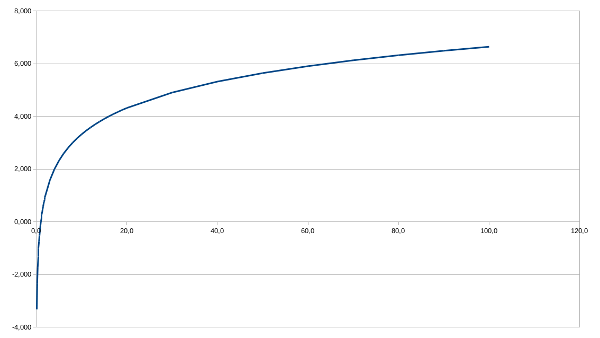

## Themen für heute

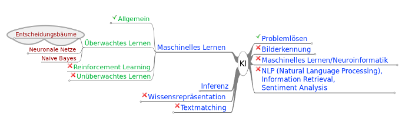

Am Ende der VL können/verstehen Sie:

- Entscheidungsbaumlerner CAL3 für nicht-disjunkte Klassen
- Nutzung des Informationsgehalts für Entscheidung bei Attributwahl (ID3)

# Entscheidungsbäume: CAL3

## CAL3: Erweiterung von CAL2 für nicht-disjunkte Klassen

1. Anfangsschritt: $\alpha^{(0)} = *$ (totales Unwissen)
2. $n$-ter Lernschritt: Objekt $v$ mit Klasse $k$
   1. Rückweisung (Endknoten mit $*$): Ersetze $*$ durch Vereinigungsklasse $/k1/$
   2. Endknoten mit Vereinigungsklasse:
      - Zähler für $k$ erhöhen, bzw.
      - $k$ mit Anzahl $1$ in Vereinigungsklasse einfügen
   - Falls Summe aller Klassen am Endknoten größer/gleich $S_1$ (Statistikschwelle):
     - Für **genau eine** Klasse gilt: $P(k | \;\tilde{x}) \ge S_2$: => Abschluss: Ersetze Vereinigungsklasse durch $k$ (für immer!)
     - Für **alle** Klassen gilt: $P(k | \;\tilde{x}) < S_2$: => Differenzierung: Ersetze Vereinigungsklasse durch neuen Test: $\kappa \gets x_{t+1}(*, \ldots, *, /k1/, *, \ldots, *)$

       $x_{t+1}$: nächstes Attribut, auf dem aktuellen Pfad $\tilde{x}$ noch nicht verwendet Symbol $k$ mit Anzahl 1 an Position $i$ wenn $x_{t+1}(v) = i$

## CAL3: Abbruchbedingungen und Parameter

- **Parameter**:
  - $S_1$: Statistikschwelle, problemabhängig wählen
  - $S_2$: $0.5 < S_2 \le 1.0$
  - Klassifikationsfehler kleiner als $1-S_2$
    - kleiner Fehler => großer Baum
    - großer Fehler => kleiner Baum
- **Abbruch**:
  - Alle Trainingsobjekte richtig klassifiziert => Kein Fehler in einem kompletten Durchlauf
  - Alle Endknoten mit eindeutigen Klassensymbolen belegt
  - Differenzierung nötig, aber alle Merkmale verbraucht
  - Lernschrittzahl überschritten

## Beispiel mit CAL3

| $x_1$ | $x_2$ | $k$ |
| --- | --- | --- |
| 0 | 0 | A |
| 0 | 1 | B |
| 0 | 1 | A |
| 1 | 0 | B |
| 1 | 1 | A |

- $S_1 = 4, S_2 = 0.7$

Tafelbeispiel CAL3

**Ergebnis**: $x_1\left(A, \; x_2(B, A)\right)$

Trainingsfehler: $1/5 = 0.2 < 1-S_2 = 1-0.7 = 0.3$

**Hinweis**: Bei nichtüberlappenden Klassen erzeugt CAL3 u.U. andere Bäume als CAL2 …

# Entscheidungsbäume: ID3

## Wie Attribute wählen?

### CAL2/CAL3

- Zyklische Iteration durch die Trainingsmenge
- Ausschließlich aktuelles Objekt betrachtet
- Reihenfolge der Attributwahl bei Verzweigung unklar

=> Betrachte die komplette Trainingsmenge!

**Relevanz** => **Informationsgehalt**

- Shannon/Weaver (1949): **Entropie**
  - Maß für die Unsicherheit einer Zufallsvariablen
  - Anzahl der Bits zur Darstellung der Ergebnisse eines Zufallsexperiments

**Beispiele**:

- Münze, die immer auf dem Rand landet: keine Unsicherheit, 0 Bit
- Faire Münze: Kopf oder Zahl: Entropie 1 Bit
- Fairer 4-seitiger Würfel: 4 mögliche Ausgänge: Entropie 2 Bit
- Münze, die zu 99% auf einer Seite landet: Entropie nahe Null

=> Anzahl der Ja/Nein-Fragen, um zur gleichen Information zu kommen

## Definition der Entropie $H(V)$ für Zufallsvariable $V$

- Zufallsvariable $V$ => mögliche Werte $v_k$
- Wahrscheinlichkeit für $v_k$ sei $p_k = P(v_k)$

$H(V) = -\sum_k p_k \log_2 p_k$

Hinweis: $\log_2 x = \frac{\log_{10} x}{\log_{10} 2} = \frac{\log x}{\log 2}$

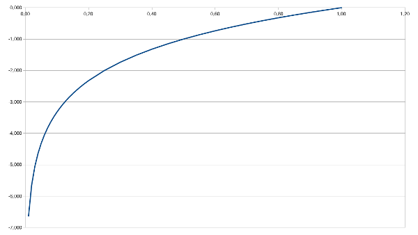

- Nur eine Klasse: $\log_2 1 = 0$ => $H(V) = 0$ Bit
- Zwei Klassen, gleichwahrscheinlich: $\log_2 0.5 = -1$ => $H(V) = 1$ Bit

## Beispiele Entropie: faire Münze

Entropie: $H(V) = -\sum_k p_k \log_2 p_k$

- $v_1 = \operatorname{Kopf}, \; v_2 = \operatorname{Zahl}$
- $p_1 = 0.5, \; p_2 = 0.5$
- $H(\operatorname{Fair}) = -(0.5 \log_2 0.5 + 0.5 \log_2 0.5) = 1$ Bit

$\log_2 0.5 = -1$

## Beispiele Entropie: unfaire Münze

Entropie: $H(V) = -\sum_k p_k \log_2 p_k$

- $v_1 = \operatorname{Kopf}, \; v_2 = \operatorname{Zahl}$
- $p_1 = 0.99, \; p_2 = 0.01$
- $H(\operatorname{UnFair}) = -(0.99 \log_2 0.99 + 0.01 \log_2 0.01)$

  $H(\operatorname{UnFair}) \approx 0.08$ Bit

$\log_2 0.01 \approx -6.64$

$\log_2 0.99 \approx -0,014$

## Beispiele Entropie: 4-seitiger Würfel

Entropie: $H(V) = -\sum_k p_k \log_2 p_k$

- $v_1 = 1, \; v_2 = 2, \; v_3 = 3, \; v_4 = 4$
- $p_1 = p_2 = p_3 = p_4 = 0.25$
- $H(\operatorname{Wuerfel}) = -4\cdot(0.25 \log_2 0.25) = 2$ Bit

$\log_2 0.25 = -2$

## Entropie der Trainingsmenge: Häufigkeit der Klassen zählen

| Nr. | $x_1$ | $x_2$ | $x_3$ | $k$ |
| --- | --- | --- | --- | --- |
| 1 | 0 | 0 | 0 | A |
| 2 | 1 | 0 | 2 | A |
| 3 | 0 | 1 | 1 | A |
| 4 | 1 | 1 | 0 | B |
| 5 | 0 | 1 | 1 | B |
| 6 | 0 | 1 | 0 | A |

- Anzahl Klasse $A$: 4
- Anzahl Klasse $B$: 2
- Gesamtzahl Beispiele: 6

Wahrscheinlichkeit für $A$: $p_A = 4/6 = 0.667$

Wahrscheinlichkeit für $B$: $p_B = 2/6 = 0.333$

$$\begin{array}{rcl}
H(S) &=& -\sum_k p_k \log_2 p_k\\
&=& -(4/6 \cdot \log_2 4/6 + 2/6 \cdot \log_2 2/6)\\
&=& -(-0.39 -0.53) = 0.92 \operatorname{Bit}
\end{array}$$

## Mittlere Entropie nach Betrachtung von Attribut $A$

$$R(S, A) = \sum_{v \in \operatorname{Values}(A)} \frac{|S_v|}{|S|} H(S_v)$$

- Auswahl von Attribut $A$ partitioniert die Trainingsmenge:
  - Je Ausprägung $v$ von $A$ erhält man eine Submenge $S_v$
- $R(S, A)$ berechnet die mittlere Entropie der Trainingsmenge, nachdem Attribut $A$ ausgewählt wurde: Unsicherheit/nötige Bits nach Auswahl von Attribut $A$

## Entropie der Trainingsmenge nach Attributwahl

| Nr. | $x_1$ | $x_2$ | $x_3$ | $k$ |
| --- | --- | --- | --- | --- |
| 1 | 0 | 0 | 0 | A |
| 2 | 1 | 0 | 2 | A |
| 3 | 0 | 1 | 1 | A |
| 4 | 1 | 1 | 0 | B |
| 5 | 0 | 1 | 1 | B |
| 6 | 0 | 1 | 0 | A |

- Sei Attribut $x_1$ ausgewählt
- $x_1$ partitioniert die Trainingsmenge
  - $x_1=0$ liefert $S_0 = \{1,3,5,6\}$
  - $x_1=1$ liefert $S_1 = \{2,4\}$
  - Häufigkeit für $x_1=0$: $4/6$
  - Häufigkeit für $x_1=1$: $2/6$
  - Gesamtzahl Beispiele: 6

$$\begin{array}{rcl}
R(S, A) &=& \sum_{v \in \operatorname{Values}(A)} \frac{|S_v|}{|S|} H(S_v)\\
&=& 4/6 \cdot H(\{1,3,5,6\}) + 2/6 \cdot H(\{2,4\})\\
&=& 4/6\cdot(-3/4 \cdot \log_2 3/4 - 1/4 \cdot \log_2 1/4) +\\
&& 2/6\cdot(-1/2 \cdot \log_2 1/2 - 1/2 \cdot \log_2 1/2)\\
&=& 0.54 + 0.33 = 0.87 \operatorname{Bit}
\end{array}$$

## Informationsgewinn durch Betrachtung von Attribut $A$

$$\begin{array}{rcl}
\operatorname{Gain}(S, A) &=& H(S) - R(S, A)\\[5pt]
&=& H(S) - \sum_{v \in \operatorname{Values}(A)} \frac{|S_v|}{|S|} H(S_v)
\end{array}$$

- $R(S,A)$: Unsicherheit/nötige Bits nach Auswahl von Attribut A
- Je kleiner $R(S,A)$, um so kleiner die **verbleibende Unsicherheit** bzw. um so kleiner die Anzahl der nötigen Bits zur Darstellung der partitionierten Trainingsmenge **nach** Betrachtung von Attribut $A$

=> Je kleiner $R(S,A)$, um so größer der Informationsgewinn

## Informationsgewinn: Kriterium zur Auswahl von Attributen

1. Informationsgewinn für alle Attribute berechnen
2. Nehme Attribut mit größtem Informationsgewinn als nächsten Test

| Nr. | $x_1$ | $x_2$ | $x_3$ | $k$ |
| --- | --- | --- | --- | --- |
| 1 | 0 | 0 | 0 | A |
| 2 | 1 | 0 | 2 | A |
| 3 | 0 | 1 | 1 | A |
| 4 | 1 | 1 | 0 | B |
| 5 | 0 | 1 | 1 | B |
| 6 | 0 | 1 | 0 | A |

$H(S) = 0.92 \operatorname{Bit}$

$$\begin{array}{rcl}
\operatorname{Gain}(S, x_1) &=& 0.92 - 0.87 = 0.05 \operatorname{Bit}\\
\operatorname{Gain}(S, x_2) &=& 0.92 - 2/6 \cdot 0 - 4/6 \cdot 1\\
&=& 0.25 \operatorname{Bit}\\
\operatorname{Gain}(S, x_3) &=& 0.92 - 3/6 \cdot 0.92 - 2/6 \cdot 1 - 1/6 \cdot 0\\
&=& 0.13 \operatorname{Bit}
\end{array}$$

Informationsgewinn für $x_2$ am höchsten => wähle $x_2$ als nächsten Test

## Entscheidungsbaumlerner ID3 (Quinlan, 1986)

```python
def ID3(examples, attr, default):
    # Abbruchbedingungen
    if examples.isEmpty():  return default
    if examples.each(class == A):  return A
    if attr.isEmpty():  return examples.MajorityValue()

    # Baum mit neuem Test erweitern
    test = MaxInformationGain(examples, attr)
    tree = new DecisionTree(test)
    m = examples.MajorityValue()
    for v_i in test:
        ex_i = examples.select(test == v_i)
        st = ID3(ex_i, attr - test, m)
        tree.addBranch(label=v_i, subtree=st)
    return tree
```

Russell und Norvig (2014): Man erhält aus dem “Decision Tree Learner” (*DTL*) den hier vorgestellten ID3-Algorithmus, wenn man die Funktion $\operatorname{ChooseAttribut}(examples, attr)$ als $\operatorname{InformationGain}(examples, attr)$ implementiert/nutzt.

Tafelbeispiel Anfang ID3

### Beispiel ID3

| Nr. | $x_1$ | $x_2$ | $x_3$ | $k$ |
| --- | --- | --- | --- | --- |
| 1 | 0 | 0 | 0 | A |
| 2 | 1 | 0 | 2 | A |
| 3 | 0 | 1 | 1 | A |
| 4 | 1 | 1 | 0 | B |
| 5 | 0 | 1 | 1 | B |
| 6 | 0 | 1 | 0 | A |

- $x2$ höchsten Information Gain
- $x2=0$ => Beispiele 1,2 => A
- $x2=1$ => Beispiele 3,4,5,6 => Information Gain berechnen, weiter teilen und verzweigen

## C4.5 als Verbesserung zu ID3

Normierter Informationsgewinn: $\operatorname{Gain}(S, A) \cdot \operatorname{Normierung}(A)$

$$\operatorname{Normierung}(A) = \frac{1}{
\sum_{v \in \operatorname{Values}(A)} p_v \log_2 \frac{1}{p_v}
}$$

## Beispiele zur Normierung bei C4.5

- Faire Münze:
  - Entropie = $H(\operatorname{Fair}) = -(0.5 \log_2 0.5 + 0.5 \log_2 0.5) = 1 \operatorname{Bit}$
  - Normierung: $1/(0.5 \log_2 (1/0.5) + 0.5 \log_2 (1/0.5)) = 1/(0.5 \cdot 1 + 0.5 \cdot 1) = 1$
- 4-seitiger Würfel:
  - Entropie = $H(\operatorname{Würfel}) = -4\cdot(0.25 \log_2 0.25) = 2 \operatorname{Bit}$
  - Normierung: $1/(4\cdot 0.25 \log_2 (1/0.25)) = 1/(4\cdot 0.25 \cdot 2) = 0.5$

=> $\operatorname{Gain}$ ist bei mehrwertigen Attributen höher

=> Normierung sorgt für fairen Vergleich der Attribute

# Zusammenfassung

## tl;dr

- CAL3: Erweiterung CAL2 für überlappende Klassen, Parameter $S_1$, $S_2$
  - Trainingsfehler wg. überlappender Klassen
- Begriff und Berechnung der Entropie: Maß für die Unsicherheit
- Begriff und Berechnung des Informationsgewinns
- Entscheidungsbaumlerner ID3
- Verbesserung durch Normierung: C4.5

**Nächste Woche**: Perzeptron, MLP (Aufbau)

## Literatur zum Weiterlesen

- Russell und Norvig (2014):
  - Lernen, Entscheidungsbäume: Abschnitt 18.1, 18.2 und 18.3
- Mitchell (2010):
  - ID3: Kapitel 3
- Der Vollständigkeit halber (Werk ist leider vergriffen und wird nicht mehr verlegt): CAL2 und CAL3 aus Unger und Wysotzki (1981)

### Bibliographie

Mitchell, T. 2010. *Machine Learning*. McGraw-Hill. ISBN: 978-0-0711-5467-3.

Russell, S.; und P. Norvig. 2014. *Artificial Intelligence: A Modern Approach*. 3rd revised edition. Pearson. ISBN: 978-1-292-02420-2. URL: http://aima.cs.berkeley.edu (zugegriffen 17.07.2018).

Unger, S.; und F. Wysotzki. 1981. *Lernfähige Klassifizierungssysteme (Classifier Systems Which Are Able to Learn)*. Berlin: Akademie-Verlag.

## Lernziele – Nach dieser Vorlesung sollten Sie …

### Anwenden (K3)

- Meta-Algorithmus CAL3 für überlappende Klassen
- Berechnung der Entropie und des Information Gain
- Entscheidungsbaumalgorithmen ID3 und C4.5

## Diese Fragen sollten Sie beantworten können …

### Entscheidungsbäume: CAL3

- Was geschieht, wenn CAL2 auf eine Trainingsmenge mit überlappenden Klassen angewendet wird?
- Zeigen Sie mit einer Handsimulation, wie CAL3 mit dem folgenden Trainingsdatensatz schrittweise einen Entscheidungsbaum generiert:

  | Beispiel | $x_1$ | $x_2$ | $x_3$ | Klasse |
  | --- | --- | --- | --- | --- |
  | 1 | a | a | a | 1 |
  | 2 | a | b | a | 2 |
  | 3 | a | a | b | 1 |
  | 4 | b | a | b | 1 |
  | 5 | a | a | c | 1 |
  | 6 | b | b | b | 2 |
  | 7 | a | a | b | 2 |

### Entscheidungsbäume: Entropie und ID3

- Vollziehen Sie die Berechnung des Informationsgewinns für die Trainingsmenge aus dieser VL Schritt für Schritt nach.
- Bauen Sie mit Hilfe von ID3 und der Beispiel-Trainingsmenge aus dieser VL einen Entscheidungsbaum auf.
  - Welches Attribut würde als nächster Test ausgewählt (und warum)?
  - Wie erfolgt der weitere Aufbau des Baumes?